# lncRNACNVIntegrateR

Neetu Tyagi, Shikha Roy, Dinesh Gupta

2024-08-15

The lncRNACNVIntegrateR integrates CNV and lncRNA data to uncover novel prognostic biomarkers. By identifying key lncRNAs affected by CNV, it provides valuable insights for personalized treatment strategies. The package includes a risk score model to assist clinicians in decision-making, potentially enhancing patient outcomes. Overall, lncRNACNVIntegrateR is an invaluable tool for studying the associations between lncRNA and CNV in cancer, offering insights into prognostic signatures.

## ‘input_cnv’

Reads the input copy number variation file for integration with lncRNA expression.

## ‘input_expr’

Reads the transcriptome gene expression file for extraction of lncRNA and protein-coding gene expression profiles, and integration with CNV.

## ‘input_clin’

Reads the clinical data file for extraction of important patient survival characteristics, used to identify survival-related lncRNA biomarkers.

## ‘input_lncRNA_positions’

Reads the lncRNA positions extracted from gtf file.

## ‘preprocessing_and_preparation’

Preprocesses the input matrices and extracts lncRNAs expression by mapping it to the GFF. Provides the final matrices used for further correlation calculation.

## ‘Correlation_lncRNA_and_CNVs’

Calculates correlation between lncRNAs expression and CNVs. Provides details for each lncRNA along with its correlation, CNV ratios, and CNV frequency.

## ‘extract_survival_related_significant_lncRNA’

Extracts survival-related lncRNAs, focusing on lncRNAs that can affect the prognosis of the patient.

## ‘visualization_of_lncRNA_and_CNVs_association’

Generates a box plot to visualize the statistical significance of CNV amplification/deletion correlating with lncRNAs expression. Filters out significant CNV-driven amplification/deletion in lncRNAs based on p-value (P <= 0.05).

## ‘Risk_score_model_development’

Performs multi-variate Cox regression analysis using significant CNV-driven lncRNAs and again filter out key lncRNAs with P-value <= 0.05 to develop a risk score model. Investigates the power of lncRNA signatures to discriminate high risk and low risk, and evaluates survival differences between the two groups.

## ‘Correlation_with_PCGs_and_functional_enrichment’

Uses identified lncRNA signatures to identify highly correlated protein coding genes based on one-to-many correlation. Performs functional enrichment analysis to relate these genes to the disease mechanism.

```r
library(lncRNACNVIntegrateR)
library(utils)
library(here)
expr_file = here("extdata", "gene_expression_COAD.txt.gz")
cnv_file = here("extdata", "CNV_data_COAD.txt.gz")
clin_file = here("extdata", "clinical_data_COAD.txt.gz")
## Reading Expression data file ###
input_expr <- function(file_path) {
  if (grepl("\\.gz$", file_path)) {
    con <- gzfile(file_path, "rt")
    x <- read.table(con, header = TRUE, sep = "\t", stringsAsFactors = FALSE)
    close(con)
  } else {
    x <- read.table(file_path, header = TRUE, sep = "\t", stringsAsFactors = FALSE)
  }
  return(x)
}
expr_df <- input_expr(expr_file)
head(expr_df[1:5,1:5])
```

```
#>                              TSPAN6 TNMD DPM1 SCYL3 C1orf112
#> TCGA-CA-6718-01A-11R-1839-07   3078    1 2104   761      719
#> TCGA-AD-6901-01A-11R-1928-07   3730  213 1899   438      197
#> TCGA-AA-A00J-01A-02R-A002-07   1206    3  640   289      169
#> TCGA-CM-4752-01A-01R-1410-07  10100   19 1793   233      187
#> TCGA-AA-3549-01A-02R-0821-07   7003   41 1169   237      231
```

```r
## Reading CNV data file ###
input_cnv <- function(file_path) {
  if (is.character(file_path)) {
    if (grepl("\\.gz$", file_path)) {
      con <- gzfile(file_path, "rt")
      y <- read.table(con, header = TRUE, sep = "\t", row.names = 1, stringsAsFactors = FALSE)
      close(con)
    } else {
      y <- read.table(file_path, header = TRUE, sep = "\t", row.names = 1, stringsAsFactors = FALSE)
    }
    y <- as.data.frame(y)
    return(y)
  } else {
    stop("Invalid input. Please provide a tab delimited file path.")
  }
}
cnv_df <- input_cnv(cnv_file)
head(cnv_df[1:5,1:5])
```

```
#>                 ACAP3 ACTRT2 AGRN ANKRD65 ATAD3A
#> TCGA-3L-AA1B-01     0      0    0       0      0
#> TCGA-4N-A93T-01    -1     -1   -1      -1     -1
#> TCGA-4T-AA8H-01     0      0    0       0      0
#> TCGA-5M-AAT4-01    -1     -1   -1      -1     -1
#> TCGA-5M-AAT5-01    -1     -1   -1      -1     -1
```

```r
## Reading Clinical data file ###
input_clin <- function(file_path) {
  if (is.character(file_path)) {
    if (grepl("\\.gz$", file_path)) {
      con <- gzfile(file_path, "rt")
      z <- read.table(con, header = TRUE, sep = "\t", row.names = 1, stringsAsFactors = FALSE)
      close(con)
    } else {
      z <- read.table(file_path, header = TRUE, sep = "\t", row.names = 1, stringsAsFactors = FALSE)
    }
    z <- as.data.frame(z)
    return(z)
  } else {
    stop("Invalid input. Please provide a correct file path.")
  }
}
clin_df <- input_clin(clin_file)
head(clin_df[1:5,1:5])
```

```
#>                       bcr_patient_uuid bcr_patient_barcode form_completion_date
#> 1                     bcr_patient_uuid bcr_patient_barcode form_completion_date
#> 2                              CDE_ID:      CDE_ID:2003301              CDE_ID:
#> 3 A94E1279-A975-480A-93E9-7B1FF05CBCBF        TCGA-3L-AA1B            2014-4-22
#> 4 92554413-9EBC-4354-8E1B-9682F3A031D9        TCGA-4N-A93T            2014-10-1
#> 5 A5E14ADD-1552-4606-9FFE-3A03BCF76640        TCGA-4T-AA8H             2014-6-5
#>            histologic_diagnosis                  prospective_collection
#> 1             histological_type tissue_prospective_collection_indicator
#> 2                CDE_ID:3081934                          CDE_ID:3088492
#> 3          Colon Adenocarcinoma                                     YES
#> 4          Colon Adenocarcinoma                                     YES
#> 5 Colon Mucinous Adenocarcinoma                                      NO
```

```r
### read lncRNA positions ###
input_lncRNA_positions <- function(file_path) {
  # Read the tab delimited file
  l <- utils::read.table(file_path, header = TRUE, sep = "\t", row.names = 1)
  l <- as.data.frame(l)
  return(l)
}

# Use the function with the predefined file path
lncRNA_positions <- input_lncRNA_positions(here("extdata", "all_lncRNAs_positions.txt"))

## First function for data preprocessing and preparation ###
preprocessing_and_preparation <- function(expr_df, cnv_df, clin_df) {
  library(DESeq2)
  library(dplyr)
  library(SummarizedExperiment)
  # Read expression data from file
  expression_data <- as.data.frame(expr_df)
  head(expression_data[1:10,1:10])

  # Shorten row names
  shortened_row_names <- substr(rownames(expression_data), 1, 12)

  # Check for duplicated shortened row names
  duplicated_shortened <- as.data.frame(duplicated(shortened_row_names))

  # Keep only the first occurrence of shortened row names and their corresponding expression data
  expression_data <- expression_data[!duplicated_shortened, ]

  rownames(expression_data) <- substr(rownames(expression_data), 1, 12)
  #return(expression_data)
  # Read CNV data from file
  # y <- input_cnv("/DATA1/descriptivestatistics/extdata/cnv_data_raw.csv")
  cnv_data <- as.data.frame(cnv_df)
  head(cnv_data[1:10,1:10])
  rownames(cnv_data) <- substr(rownames(cnv_data), 1, 12)
  for (i in 1:nrow(cnv_data)) {
    current_row_name <- rownames(cnv_data)[i]
    if (current_row_name != "-") {
      rownames(cnv_data)[i] <- gsub("\\.", "-", current_row_name)
    }
  }

  # Read clinical data from file
  clinical_data <- clin_df
  head(clinical_data[1:10,1:10])
  colnames(clinical_data) <- clinical_data[1,]
  clinical_data <- clinical_data[-(1:2),]
  selected_clin <- as.data.frame(clinical_data[, c("bcr_patient_barcode", "vital_status", "days_to_last_followup")])
  rownames(selected_clin) <- selected_clin[,1]
  selected_clin <- selected_clin[,-1]

  # Find common samples between CNV and expression data
  common_samples <- intersect(rownames(cnv_data), rownames(expression_data))

  if (length(common_samples) == 0) {
    stop("No common samples found between CNV and expression data.")
  }

  # Extract common samples from expression data
  #  df_gene_expr_data.t <- expression_data[common_samples, ]

  # Extract common samples from CNV data
  #  CNV_data_transposed <- cnv_data[common_samples, ]

  ### Fetch common samples from Clinical data ###
  clin_selected <- selected_clin[common_samples, ]
  clin_selected <- na.omit(clin_selected)
  #clin_selected <- clin_selected[!(clin_selected$days_to_last_followup == "[Not Available]"), ]
  raw_names_clin_data_avail <- rownames(clin_selected)

  head(clin_selected)

  ### now select the expression and CNV data for final common samples i.e., 483 ###

  df_gene_expr_data.t <- expression_data[raw_names_clin_data_avail, ]

  # Extract common samples from CNV data
  CNV_data_transposed <- cnv_data[raw_names_clin_data_avail, ]

  # Create metadata for DESeq2
  df_gene_expr_data.t2 <- t(df_gene_expr_data.t)
  column2 <- as.data.frame(colnames(df_gene_expr_data.t2))
  condn2 <- as.data.frame(rep("Case", times = nrow(column2)))
  metaData2 <- cbind(column2, condn2)
  colnames(metaData2)[1:2] <- c("Sample", "condition")

  # Create a DESeqDataSet object
  dds <- DESeq2::DESeqDataSetFromMatrix(df_gene_expr_data.t2, metaData2, design = ~1)
  # Run DESeq2
  ddsDE <- DESeq2::DESeq(dds)
  # Apply Variance Stabilizing Transformation
  vst_normal <- DESeq2::varianceStabilizingTransformation(ddsDE, blind = TRUE)
  vst_normal_results <- SummarizedExperiment::assay(vst_normal)
  ## firstly download the gtf file from gencode ####
  # URL to the GTF file (GENCODE version 22)
  gtf_url <- "https://ftp.ebi.ac.uk/pub/databases/gencode/Gencode_human/release_22/gencode.v22.annotation.gtf.gz"

  # Destination file path where you want to save the downloaded file
  # Get the current working directory
  current_working_directory <- getwd()

  # Set the destination path to the current working directory
  destination_path <- file.path(current_working_directory, "gencode.v22.annotation.gtf.gz")

  # Download the GTF file with a longer timeout
  download.file(url = gtf_url, destfile = destination_path, method = "wget", timeout = timeout_duration)

  # Uncompress the downloaded file if it's in .gz format
  if (grepl(".gz$", destination_path)) {
    system(paste("gunzip", destination_path))
    destination_path <- sub(".gz$", "", destination_path)
  }

  # Check if the download was successful
  if (file.exists(destination_path)) {
    cat("Downloaded GTF file successfully.\n")

    # Read the downloaded GTF file into a data frame
    gtf <- read.table(destination_path, header = FALSE, sep = "\t")

    # Optionally, you can add column names to the data frame if your GTF file doesn't have a header row
    # colnames(gtf) <- c("seqname", "source", "feature", "start", "end", "score", "strand", "frame", "attribute")

    # Now you have a data frame named "gtf" that you can process further
  } else {
    cat("Download failed. Please check the URL or your internet connection.\n")
  }
 # head(gtf[1:5,1:5])
 split_names <- strsplit(as.character(gtf$V9), ';')
 merged_df <- do.call(rbind, split_names)
  # Combine the merged columns with the original data frame
 df_merged <- cbind(gtf, merged_df)
  # Filter and subset lncRNA transcripts
  matched_processed_transcript <- subset(df_merged, grepl("processed_transcript", df_merged$'2', ignore.case = TRUE))
  prime_overlapping_ncrna <- subset(df_merged, grepl("3prime_overlapping_ncrna", df_merged$'2', ignore.case = TRUE))
  sense_intronic <- subset(df_merged, grepl("sense_intronic", df_merged$'2', ignore.case = TRUE))
  sense_overlapping <- subset(df_merged, grepl("sense_overlapping", df_merged$'2', ignore.case = TRUE))
  antisense <- subset(df_merged, grepl("antisense", df_merged$'2', ignore.case = TRUE))
  lncRNA <- subset(df_merged, grepl("lincRNA", df_merged$'2', ignore.case = TRUE))

  # Combine all lncRNA subsets into one data frame
  All_lnc <- rbind(matched_processed_transcript, prime_overlapping_ncrna, sense_intronic, sense_overlapping, antisense, lncRNA)

  # Extract and clean lncRNA names
  All_lnc_names <- as.data.frame(All_lnc$'4')
  All_lnc_names <- gsub("gene_name", "", All_lnc_names$`All_lnc$"4"`)
  All_lnc_names2 <- as.data.frame(All_lnc_names)
  All_lnc_names2_uniq <- unique(All_lnc_names2)
  colnames(All_lnc_names2_uniq)[colnames(All_lnc_names2_uniq) == "All_lnc_names"] <- "Name"

  ### Now fetch for PCGs ###

  Protein_coding_genes <- subset(df_merged, grepl("protein_coding", df_merged$'2', ignore.case = TRUE))
  All_PCG_names <- as.data.frame(Protein_coding_genes$'4')
  All_PCG_names <- gsub("gene_name", "", All_PCG_names$`Protein_coding_genes$"4"`)
  All_PCG_names2 <- as.data.frame(All_PCG_names)
  All_PCG_names2_uniq <- unique(All_PCG_names2)
  colnames(All_PCG_names2_uniq)[colnames(All_PCG_names2_uniq) == "All_PCG_names"] <- "Name"

  # Extract gene names from All_lnc_names2_uniq
  PCG_names <- as.data.frame(trimws(All_PCG_names2_uniq$Name))  # Remove leading/trailing whitespaces


  # Now fetch the lncRNAs expression and CNV data from common samples
  # library(dplyr)

  vst_normal_results <- as.data.frame(t(vst_normal_results))
  gene_names <- as.data.frame(trimws(All_lnc_names2_uniq$Name))  # Remove leading/trailing whitespaces
  column_names <- as.data.frame(colnames(vst_normal_results))


  # Find the intersection of gene names and column names
  intersecting_genes <- intersect(gene_names$`trimws(All_lnc_names2_uniq$Name)`, column_names$`colnames(vst_normal_results)`)
  # Now you can use the select function
  result_df_Expr_lncRNAs <- vst_normal_results %>%
    select(all_of(intersecting_genes))

  # Find the intersection of gene names and column names
  intersecting_genes_PCGs <- intersect(PCG_names$`trimws(All_PCG_names2_uniq$Name)`, column_names$`colnames(vst_normal_results)`)
  # Now you can use the select function
  result_df_Expr_PCGs <- vst_normal_results %>%
    select(all_of(intersecting_genes_PCGs))
  # write.table(result_df_Expr_PCGs, "result_df_Expr_PCGs.txt", sep="\t", quote=FALSE)

  # Extract CNV data
  common_CNV_data <- as.data.frame(CNV_data_transposed)
  column_names_CNV <- as.data.frame(colnames(CNV_data_transposed))
  intersecting_genes_CNV <- intersect(gene_names$`trimws(All_lnc_names2_uniq$Name)`, column_names_CNV$`colnames(CNV_data_transposed)`)
  result_df_CNVs <- common_CNV_data %>% select(all_of(intersecting_genes_CNV))

  # Fetch lncRNAs expression only for those which have CNV call also
  col_new_lncRNA <- as.data.frame(colnames(result_df_Expr_lncRNAs))
  common_genes <- intersect(intersecting_genes_CNV, col_new_lncRNA$`colnames(result_df_Expr_lncRNAs)`)

  # Intersect genes that have expression also from the CNV data
  result_df_Expr_lncRNAs <- result_df_Expr_lncRNAs %>%
    select(all_of(common_genes))
  ### expression final matrix lncRNA ###
  head(result_df_Expr_lncRNAs[1:10,1:10])

  # Also fetch these from CNV as the number is not the same when fetched from expression data
  result_df_Expr_lncRNAs_with_CNV <- result_df_CNVs %>%
    select(all_of(common_genes))
  ### CNVs final matrix ###
  head(result_df_Expr_lncRNAs_with_CNV[1:10,1:10])

  # Return the data frames as a list
  return(list(result_df_Expr_lncRNAs = result_df_Expr_lncRNAs,
              result_df_Expr_lncRNAs_with_CNV = result_df_Expr_lncRNAs_with_CNV,
              clin_selected = clin_selected, PCG_matrix = result_df_Expr_PCGs))
}
# usage
preprocessing_and_preparation_result <- preprocessing_and_preparation(expr_df, cnv_df, clin_df)
```

```
#>
#>
#> Warning in DESeq2::DESeq(dds): the design is ~ 1 (just an intercept). is this
#> intended?
#> -- replacing outliers and refitting for 9818 genes
#> -- DESeq argument 'minReplicatesForReplace' = 7
#> -- original counts are preserved in counts(dds)
#> Downloaded GTF file successfully.
#> Warning in rbind(...): number of columns of result is not a multiple of vector
#> length (arg 1)
```

```r
lncRNA_expre_df <- preprocessing_and_preparation_result$result_df_Expr_lncRNAs
head(lncRNA_expre_df[1:5,1:5])
```

```
#>                  GAS5 MIR205HG LINC00692 LINC00955    DANCR
#> TCGA-3L-AA1B 12.99340 4.244939  2.617266  3.401638 10.57960
#> TCGA-4N-A93T 12.51295 3.099276  2.617266  3.444635 10.24113
#> TCGA-4T-AA8H 12.17270 2.617266  2.617266  2.617266 10.64304
#> TCGA-5M-AAT4 13.34098 3.393956  2.617266  3.510638 10.22078
#> TCGA-5M-AAT6 12.54132 8.302659  2.617266  2.617266 10.48174
```

```r
lncRNA_CNV_df <- preprocessing_and_preparation_result$result_df_Expr_lncRNAs_with_CNV
head(lncRNA_CNV_df[1:5,1:5])
```

```
#>              GAS5 MIR205HG LINC00692 LINC00955 DANCR
#> TCGA-3L-AA1B    0        0         0         1     1
#> TCGA-4N-A93T    0        0         0        -1    -1
#> TCGA-4T-AA8H    0        1         1         0     0
#> TCGA-5M-AAT4    0        0        -1        -1    -1
#> TCGA-5M-AAT6    0        0         0         0     0
```

```r
clin_selected <- preprocessing_and_preparation_result$clin_selected
head(clin_selected)
```

```
#>              vital_status days_to_last_followup
#> TCGA-3L-AA1B        Alive                   154
#> TCGA-4N-A93T        Alive                     8
#> TCGA-4T-AA8H        Alive                   160
#> TCGA-5M-AAT4         Dead       [Not Available]
#> TCGA-5M-AAT6         Dead       [Not Available]
#> TCGA-5M-AATE        Alive                  1200
```

```r
PCG_matrix <- preprocessing_and_preparation_result$PCG_matrix
head(PCG_matrix[1:5,1:5])
```

```
#>                 OR4F5   OR4F29   OR4F16   SAMD11    NOC2L
#> TCGA-3L-AA1B 2.617266 2.617266 2.617266 7.112707 11.48086
#> TCGA-4N-A93T 2.617266 2.617266 2.617266 4.818667 11.18282
#> TCGA-4T-AA8H 2.617266 2.617266 2.617266 4.509899 11.87434
#> TCGA-5M-AAT4 2.617266 2.617266 2.617266 5.637257 11.89901
#> TCGA-5M-AAT6 2.617266 2.617266 2.617266 6.433041 12.34630
```

[output not shown]

[output cut: 14 more lines]

[output not shown]

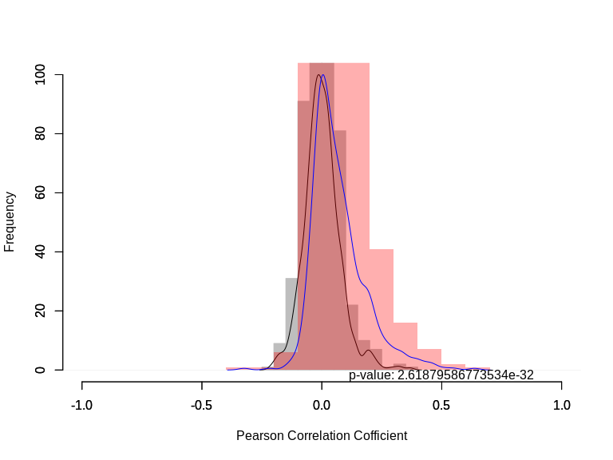

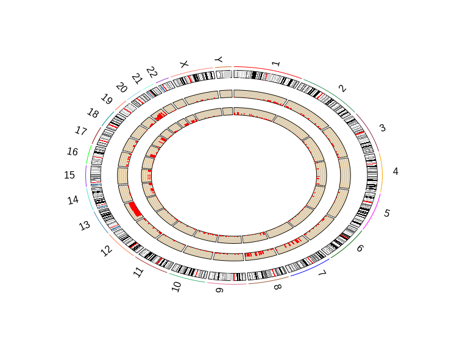

```r
### Second function calculating correlation between CNV and lncRNA expression ####
Correlation_lncRNAs_and_CNVs <- function(lncRNA_expre_df, lncRNA_CNV_df) {
library(devtools)
library(basicPlotteR)
  df1.t <- as.data.frame(t(lncRNA_expre_df))
  df2.t <- as.data.frame(t(lncRNA_CNV_df))
  # Sort the data frames
  df1_sorted <- df1.t[order(rownames(df1.t)), order(names(df1.t))]
  df2_sorted <- df2.t[order(rownames(df2.t)), order(names(df2.t))]
  df2_subset <- as.data.frame(lapply(df2_sorted[1:nrow(df2_sorted), 1:ncol(df2_sorted)], as.numeric))
  rownames(df2_subset) <- rownames(df2_sorted)
all.pcc=c()
for(i in 1:nrow(df2_subset)){
  all.pcc=c(all.pcc,cor(as.numeric(df2_subset[i,]),as.numeric(df1_sorted[i,]))[1])
 }
 all.pcc.rand=c()
rand.cnv.inds=sample(1:nrow(df2_subset),nrow(df2_subset))
rand.lnc.inds=sample(1:nrow(df1_sorted),nrow(df1_sorted))
for(i in 1:nrow(df2_subset)){
 all.pcc.rand=c(all.pcc.rand,cor(as.numeric(df2_subset[rand.cnv.inds,][i,]),as.numeric(df1_sorted[rand.lnc.inds,][i,]))[1])
 }
hist(as.numeric(all.pcc.rand[!is.na(all.pcc.rand)]),
     col='grey', xlim=c(-1,1), ylim=c(0,100),
     border='grey', xlab='Pearson Correlation Cofficient', ylab='Frequency', main='')
# Add main title at specific coordinates (adjust xjust and yjust as needed)
mtext(text = "Random", side = 3, xjust = 0.2, yjust = 0.5, line = 20)
par(new=T)
plot(density(all.pcc.rand[!is.na(all.pcc.rand)]),
     xlim=c(-1,1), col='black', xlab='', ylab='', axes=FALSE, main='')
par(new=T)
hist(as.numeric(all.pcc[!is.na(all.pcc)]),
     col=rgb(255, 0, 0, 80, maxColorValue=255),
     xlim=c(-1,1), ylim=c(0,100),
     border=NA, xlab='', ylab='', main='')
mtext(text = "LncRNA-CNV", side = 2, xjust = 0.6, yjust = 0.5, line = 20)
par(new=T)
plot(density(all.pcc[!is.na(all.pcc)]),
     xlim=c(-1,1), col='blue', xlab='', ylab='', axes=FALSE, main='')
t_test_result <- t.test(all.pcc.rand, all.pcc)
# Extract p-value from t-test result
p_value <- t_test_result$p.value

# Add legend
#legend("topright", legend = c("Random", "Actual"), fill = c("gray", "red"))

# Add text annotation for p-value below the plot
text(x = 0.5, y = -0.1, labels = paste("p-value:", p_value),
     col = "black", hjust = "left")
corr_data <- as.data.frame(all.pcc)
rownames(corr_data) <- rownames(df2_subset)
colnames(corr_data) <- "corr"
# Add correlation and frequency details to CNV values
  Final_matrix_CNV_plus_corr <- cbind(df2_subset, corr_data)
  New_matrix_with_only_positive_values <- Final_matrix_CNV_plus_corr[Final_matrix_CNV_plus_corr$corr > 0, ]
  New_matrix_with_only_positive_values_1 <- na.omit(New_matrix_with_only_positive_values)

  # Remove correlation column
  New_matrix_with_only_positive_values_1 <- New_matrix_with_only_positive_values_1[, -ncol(New_matrix_with_only_positive_values_1)]
  # Calculate amp/del ratios and frequency of CNVs
  max_value <- max(as.matrix(New_matrix_with_only_positive_values_1))
  min_value <- min(as.matrix(New_matrix_with_only_positive_values_1))
  count_numbers <- function(row) {
    counts <- table(row)
    names(counts) <- paste(names(counts), "count", sep = "_")
    return(counts)
  }
  counts_list <- apply(New_matrix_with_only_positive_values_1, 1, count_numbers)
  unique_values <- unique(unlist(New_matrix_with_only_positive_values_1))
  counts_df <- data.frame(matrix(0, nrow = nrow(New_matrix_with_only_positive_values_1), ncol = length(unique_values)))
  colnames(counts_df) <- unique_values
  for (i in 1:length(counts_list)) {
    counts_df[i, names(counts_list[[i]])] <- counts_list[[i]]
  }
  counts_df <- counts_df[, -(1:5)]
  counts_df[is.na(counts_df)] <- 0

  New_matrix_with_counts <- cbind(New_matrix_with_only_positive_values_1, counts_df)
  New_matrix_with_counts$sum_del <- rowSums(New_matrix_with_counts[, c("-2_count", "-1_count")])
  New_matrix_with_counts$sum_amp <- rowSums(New_matrix_with_counts[, c("1_count", "2_count")])
  New_matrix_with_counts$ratio_amp_del <- New_matrix_with_counts$sum_amp / New_matrix_with_counts$sum_del
  New_matrix_with_counts$CNV_frequency <- rowSums(New_matrix_with_counts[, c("sum_amp", "sum_del")]) / ncol(New_matrix_with_only_positive_values_1) * 100

  # Add the correlation details
  New_matrix_with_counts <- merge(New_matrix_with_counts, corr_data, by = "row.names")

  # Sort the data frame based on correlation and frequency columns
  New_matrix_with_counts <- New_matrix_with_counts[with(New_matrix_with_counts, order(-corr, -CNV_frequency)), ]
  rownames(New_matrix_with_counts) <- New_matrix_with_counts[, 1]
  New_matrix_with_counts <- New_matrix_with_counts[, -1]

  #### at last fetch these lncRNAs expression data from total lncRNA data in previous function ####
  fetch_lnc_names <- rownames(New_matrix_with_counts)
  final_lncRNAs_after_corr_list_expre <- df1.t[fetch_lnc_names, ]
  #write.table(final_lncRNAs_after_corr_list_expre, "final_expression_data.txt", sep = "\t", quote = FALSE, row.names = TRUE)
  ### adding the circos part ####
new_matrix <- New_matrix_with_counts[, -seq(ncol(New_matrix_with_counts) - 9, ncol(New_matrix_with_counts))]
### for deletion ###
new_matrix$Data <- apply(new_matrix, 1, function(x) {
    sum(x == -1) / length(x)
})
new_matrix_del_info <- new_matrix
### for amplification ###
new_matrix <- new_matrix[, -ncol(new_matrix)]
new_matrix$Data <- apply(new_matrix, 1, function(x) {
    sum(x == 1) / length(x)
})
new_matrix_amp_info <- new_matrix
new_matrix_amp_info_1 <- data.frame(Data = new_matrix_amp_info[, ncol(new_matrix_amp_info)])
rownames(new_matrix_amp_info_1) <- rownames(new_matrix_amp_info)

new_matrix_del_info_1 <- data.frame(Data = new_matrix_del_info[, ncol(new_matrix_del_info)])
rownames(new_matrix_del_info_1) <- rownames(new_matrix_del_info)

### directly access the lncRNA positions already stored from the input_lncRNA function
lnc.locs.del <- merge(lncRNA_positions, new_matrix_del_info_1, by = "row.names")
 rownames(lnc.locs.del) <- lnc.locs.del[, 1]
  lnc.locs.del <- lnc.locs.del[, -1]
lnc.locs.amp <- merge(lncRNA_positions, new_matrix_amp_info_1, by = "row.names")
rownames(lnc.locs.amp) <- lnc.locs.amp[, 1]
  lnc.locs.amp <- lnc.locs.amp[, -1]
### row run the circos code ###
library(RCircos)
data(UCSC.HG38.Human.CytoBandIdeogram)
data(RCircos.Histogram.Data)
RCircos.Set.Core.Components(cyto.info = UCSC.HG38.Human.CytoBandIdeogram, chr.exclude = NULL, tracks.inside = 5, tracks.outside = 0)
RCircos.Set.Plot.Area()
RCircos.Chromosome.Ideogram.Plot()
# Assuming lnc.locs.amp and lnc.locs.del are properly formatted data frames
RCircos.Histogram.Plot(lnc.locs.amp, data.col = 4, track.num = 2, side = 'in', max.value = 1)
RCircos.Histogram.Plot(lnc.locs.del, data.col = 4, track.num = 4, max.value = 1)
# Inner circle represents amplification and the outer circle represents the deletion.
  Correlation_lncRNAs_and_CNVs_results <- list(
    t_test_result = t_test_result,
    final_matrix = New_matrix_with_counts,
    final_expre_data = final_lncRNAs_after_corr_list_expre
  )
  return(Correlation_lncRNAs_and_CNVs_results)
}
# usage
Correlation_lncRNAs_and_CNVs_results <- Correlation_lncRNAs_and_CNVs(lncRNA_expre_df, lncRNA_CNV_df)
```

```r
## View output function 2
final_expression_data <- Correlation_lncRNAs_and_CNVs_results$final_expre_data
head(final_expression_data[1:5,1:5])
```

```
#>           TCGA-3L-AA1B TCGA-4N-A93T TCGA-4T-AA8H TCGA-5M-AAT4 TCGA-5M-AAT6
#> SNHG11         9.13073     9.545129     7.958639     8.815767     8.125889
#> SPATA13       11.01411    11.494530    11.354615    10.508671     9.925927
#> LINC00909      7.77512     7.800594     6.910837     7.439476     7.483442
#> LINC00525      6.16692     5.116492     3.939955     5.740592     4.102859
#> LINC00589      4.97841     3.099276     4.583212     3.510638     3.162763
```

```r
New_matrix_with_counts  <- Correlation_lncRNAs_and_CNVs_results$final_matrix
head(New_matrix_with_counts[1:5,1:5])
```

```
#>           TCGA.3L.AA1B TCGA.4N.A93T TCGA.4T.AA8H TCGA.5M.AAT4 TCGA.5M.AAT6
#> SNHG11               1            1            0            1            0
#> SPATA13              1            1            1            0            1
#> LINC00909           -1           -1           -1           -2            0
#> LINC00525            1            1            1            1            0
#> LINC00589            1           -1            1           -1           -1
```

```r
### Third function ###
extract_survival_related_significant_lncRNA <- function(lncRNA_expression, clinical_data, New_matrix_with_CNV_counts) {

  expression_data.t <- t(lncRNA_expression)
  merged_df_fetched_lncRNAs_expression <- merge(expression_data.t, clinical_data, by = "row.names")
  rownames(merged_df_fetched_lncRNAs_expression) <- merged_df_fetched_lncRNAs_expression[, 1]
  merged_df_fetched_lncRNAs_expression <- merged_df_fetched_lncRNAs_expression[, -1]

  # Process vital_status column
  merged_df_fetched_lncRNAs_expression$vital_status <- ifelse(merged_df_fetched_lncRNAs_expression$vital_status == "Dead", 0, 1)
  #merged_df_fetched_lncRNAs_expression$biochemical_recurrence <- ifelse(merged_df_fetched_lncRNAs_expression$biochemical_recurrence == "NO", 0, 1)

  merged_df_fetched_lncRNAs_expression <- as.data.frame(merged_df_fetched_lncRNAs_expression)
  # merged_df_fetched_lncRNAs_expression <- merged_df_fetched_lncRNAs_expression[!(merged_df_fetched_lncRNAs_expression$days_to_last_followup == "[Not Available]"), ]
  merged_df_fetched_lncRNAs_expression$days_to_last_followup <- as.numeric(merged_df_fetched_lncRNAs_expression$days_to_last_followup)
  #merged_df_fetched_lncRNAs_expression <- merged_df_fetched_lncRNAs_expression[, !names(merged_df_fetched_lncRNAs_expression) %in% c("vital_status")]
  merged_df_fetched_lncRNAs_expression$days_to_last_followup <- as.numeric(merged_df_fetched_lncRNAs_expression$days_to_last_followup)
  merged_df_fetched_lncRNAs_expression[is.na(merged_df_fetched_lncRNAs_expression)] <- 0
library(RegParallel)
  res <- RegParallel(
    data = merged_df_fetched_lncRNAs_expression,
    formula = 'Surv(days_to_last_followup, vital_status) ~ [*]',
    FUN = function(formula, data)
      coxph(formula = formula,
            data = data,
            ties = 'breslow',
            singular.ok = TRUE),
    FUNtype = 'coxph',
    variables = colnames(merged_df_fetched_lncRNAs_expression)[1:ncol(merged_df_fetched_lncRNAs_expression)],
    blocksize = 30,
    cores = 2,
    nestedParallel = FALSE,
    conflevel = 95)

  # Extract significant genes related to survival
  res_sig <- res[res$P <= 0.05, ]
  res_sig <- res_sig[-nrow(res_sig), ]
  ### extract the survival related lncRNA data from the final corr data matrix ###
  lncRNA_ids_survival_related_sign <- as.data.frame(res_sig$Variable)
  #View(lncRNA_ids_survival_related_sign)
  colnames(lncRNA_ids_survival_related_sign) <- "Names"
  rownames(lncRNA_ids_survival_related_sign) <- lncRNA_ids_survival_related_sign[, 1]

  ### Now fetch these lncRNAs CNV data from our final generated table with all information ###
  merged_df_neww_with_sign_lncRNA_surv_related <- merge(lncRNA_ids_survival_related_sign, New_matrix_with_CNV_counts, by = "row.names")
  rownames(merged_df_neww_with_sign_lncRNA_surv_related) <- merged_df_neww_with_sign_lncRNA_surv_related[, 1]
  merged_df_neww_with_sign_lncRNA_surv_related <- merged_df_neww_with_sign_lncRNA_surv_related[, -(1:2)]

  ### sort on the basis of correlation and CNV frequency ###
  merged_df_neww_with_sign_lncRNA_surv_related_1 <- merged_df_neww_with_sign_lncRNA_surv_related[with(merged_df_neww_with_sign_lncRNA_surv_related, order(-corr, -CNV_frequency)), ]

  ### also extract the survival related lncRNAs expression ###

  result_df_Expr_lncRNAs_surv_related <- merge(lncRNA_ids_survival_related_sign, lncRNA_expression, by = "row.names")
  rownames(result_df_Expr_lncRNAs_surv_related) <- result_df_Expr_lncRNAs_surv_related[,1]
  result_df_Expr_lncRNAs_surv_related <- result_df_Expr_lncRNAs_surv_related[,-(1:2)]
  # Return both the data frame with survival-related lncRNAs and the list of lncRNA IDs
  return(list(data = merged_df_neww_with_sign_lncRNA_surv_related_1,
              ids = lncRNA_ids_survival_related_sign,
              final_expr = result_df_Expr_lncRNAs_surv_related,
              merged_expr_clinical = merged_df_fetched_lncRNAs_expression,
              res_sign = res_sig
              ))
}
result_surv <- extract_survival_related_significant_lncRNA(final_expression_data, clin_selected, New_matrix_with_counts)
final_expression_data_surv_related <- result_surv$final_expr
head(final_expression_data_surv_related[1:5,1:5])
```

```
#>           TCGA-3L-AA1B TCGA-4N-A93T TCGA-4T-AA8H TCGA-5M-AAT4 TCGA-5M-AAT6
#> BCYRN1        4.644892     3.859729     3.470909     3.393956     3.162763
#> BMS1P4        4.296453     4.084551     4.952351     4.664547     3.810049
#> C10orf95      3.519406     3.444635     3.808093     3.069272     3.551332
#> C11orf72      3.073814     3.295833     3.225218     3.393956     3.551332
#> C14orf132     8.239006     5.283839     6.017245     5.867522     7.897747
```

```r
merged_df_neww_with_sign_lncRNA_surv_related_1 <- result_surv$data
head(merged_df_neww_with_sign_lncRNA_surv_related_1[1:5,1:5])
```

```
#>           TCGA.3L.AA1B TCGA.4N.A93T TCGA.4T.AA8H TCGA.5M.AAT4 TCGA.5M.AAT6
#> LINC00963            0            0            0            0            0
#> SNHG15               1            1            1            1            0
#> LINC00265            1            1            1            1            0
#> HCG18                0            0            0            0            0
#> LINC00324           -1           -1            1           -1            0
```

```r
merged_expression_clinical_data <- result_surv$merged_expr_clinical
head(merged_expression_clinical_data[1:5,1:5])
```

```
#>                SNHG11   SPATA13 LINC00909 LINC00525 LINC00589
#> TCGA-3L-AA1B 9.130730 11.014110  7.775120  6.166920  4.978410
#> TCGA-4N-A93T 9.545129 11.494530  7.800594  5.116492  3.099276
#> TCGA-4T-AA8H 7.958639 11.354615  6.910837  3.939955  4.583212
#> TCGA-5M-AAT4 8.815767 10.508671  7.439476  5.740592  3.510638
#> TCGA-5M-AAT6 8.125889  9.925927  7.483442  4.102859  3.162763
```

```r
significant_lncRNA_stats <- result_surv$res_sign
head(significant_lncRNA_stats[1:10,1:10])
```

```
#>     Variable      Term       Beta StandardError         Z            P
#>       <char>    <char>      <num>         <num>     <num>        <num>
#> 1: LINC00963 LINC00963  0.2258333    0.09359035  2.412997 0.0158219313
#> 2:    SNHG15    SNHG15 -0.1744907    0.07768929 -2.246007 0.0247035341
#> 3: LINC00265 LINC00265 -0.1809466    0.05926779 -3.053034 0.0022654001
#> 4:     HCG18     HCG18 -0.3108578    0.09087031 -3.420895 0.0006241536
#> 5: LINC00324 LINC00324  0.1534345    0.06481009  2.367448 0.0179112352
#> 6:   MIR17HG   MIR17HG -0.1280990    0.04439897 -2.885180 0.0039119025
#>             LRT         Wald      LogRank        HR
#>           <num>        <num>        <num>     <num>
#> 1: 0.0157735616 0.0158219313 0.0158104217 1.2533667
#> 2: 0.0248433297 0.0247035341 0.0248471873 0.8398846
#> 3: 0.0023934461 0.0022654001 0.0022601857 0.8344799
#> 4: 0.0003466775 0.0006241536 0.0006855467 0.7328181
#> 5: 0.0184960732 0.0179112352 0.0178746096 1.1658315
#> 6: 0.0035669770 0.0039119025 0.0040012832 0.8797663
```

```r
### fourth function ###
visualization_of_lncRNA_and_CNVs_association <- function(lncRNA_expression_data_surv_related, lncRNAs_surv_related_CNV_details) {
library(ggplot2)
library(purrr)
library(ggpubr)
library(dplyr)
  # Extracting the expression data
  vst_data <- lncRNA_expression_data_surv_related
  colnames(vst_data) <- gsub("-", ".", colnames(vst_data))
  lncRNA_list <- rownames(lncRNAs_surv_related_CNV_details)

  # Create a directory to save separate expression files
  dir.create("lncRNA_expression_files", showWarnings = FALSE)

  # Loop through the lncRNA list and save separate expression files
  for (lncRNA_name in lncRNA_list) {
    if (lncRNA_name %in% rownames(vst_data)) {
      lncRNA_expression <- vst_data[lncRNA_name, , drop = FALSE]
      file_name <- paste("lncRNA_expression_files", "/", lncRNA_name, "_expression.txt", sep = "")
      write.table(lncRNA_expression, file_name, sep = "\t", row.names = TRUE, col.names = TRUE)
      cat(paste("Saved expression for", lncRNA_name, "to", file_name, "\n"))
    } else {
      cat(paste("lncRNA", lncRNA_name, "not found in the data\n"))
    }
  }

  # Get CNV details for violin plot generation
  output_directory <- "lncRNA_files"
  dir.create(output_directory, recursive = TRUE)

  # Step 1: Read the CNV data file
  cnv_data <- lncRNAs_surv_related_CNV_details[, grepl("^TCGA", colnames(lncRNAs_surv_related_CNV_details))]

  # Step 2: Extract TCGA sample names
  sample_names <- colnames(cnv_data)
  amplification_samples <- list()
  deletion_samples <- list()
  normal_samples <- list()

  # Step 3: Categorize samples based on CNV values for each lncRNA
  for (lncRNA_name in rownames(cnv_data)) {
    lncRNA_cnv_values <- cnv_data[lncRNA_name, ]
    amplification_samples[[lncRNA_name]] <- sample_names[lncRNA_cnv_values > 0]
    deletion_samples[[lncRNA_name]] <- sample_names[lncRNA_cnv_values < 0]
    normal_samples[[lncRNA_name]] <- sample_names[lncRNA_cnv_values == 0]
  }

  # Step 4: Store the sample names in each category
  categories <- list(
    amplification = amplification_samples,
    deletion = deletion_samples,
    normal = normal_samples
  )
  lncRNA_names <- lncRNA_list
  for (lncRNA_name in lncRNA_names) {
    for (category_name in names(categories)) {
      file_name <- paste(lncRNA_name, category_name, ".txt", sep = "_")
      file_path <- file.path(output_directory, file_name)
      writeLines(categories[[category_name]][[lncRNA_name]], con = file_path)
    }
  }

  cat("Text files have been created and saved in the directory:", output_directory, "\n")

  # Fetch expression for each category
  input_expression_directory <- "lncRNA_expression_files"
  input_cnv_directory <- "lncRNA_files"
  output_data_directory <- "lncRNA_category_data"
  dir.create(output_data_directory, showWarnings = FALSE)

  for (lncRNA_name in lncRNA_names) {
    for (category_name in c("normal", "amplification", "deletion")) {
      expression_file <- file.path(input_expression_directory, paste0(lncRNA_name, "_expression.txt"))
      category_file <- file.path(input_cnv_directory, paste0(lncRNA_name, "_", category_name, "_.txt"))

      if (file.exists(expression_file) && file.exists(category_file)) {
        expression_data <- read.table(expression_file, header = TRUE, sep = "\t", row.names = 1)
        category_samples <- readLines(category_file)
        category_expression <- expression_data[, category_samples, drop = FALSE]
        output_file <- file.path(output_data_directory, paste0(lncRNA_name, "_", category_name, "_data.txt"))
        write.table(category_expression, output_file, sep = "\t", row.names = TRUE, col.names = TRUE)
        cat(paste("Saved category data for", lncRNA_name, "(", category_name, ") to", output_file, "\n"))
      } else {
        cat(paste("Expression or category file not found for", lncRNA_name, "(", category_name, ")\n"))
      }
    }
  }

  cat("Category data files have been created and saved in the directory:", output_data_directory, "\n")

  # Merge normal and amplification, and normal and deletion
  input_data_directory <- "lncRNA_category_data"
  output_merged_directory <- "merged_category_data"
  dir.create(output_merged_directory, showWarnings = FALSE)

  for (lncRNA_name in lncRNA_names) {
    normal_file <- file.path(input_data_directory, paste0(lncRNA_name, "_normal_data.txt"))
    amplification_file <- file.path(input_data_directory, paste0(lncRNA_name, "_amplification_data.txt"))
    deletion_file <- file.path(input_data_directory, paste0(lncRNA_name, "_deletion_data.txt"))

    if (file.exists(normal_file) && file.exists(amplification_file) && file.exists(deletion_file)) {
      normal_data <- read.table(normal_file, header = TRUE, sep = "\t", row.names = 1)
      amplification_data <- read.table(amplification_file, header = TRUE, sep = "\t", row.names = 1)
      deletion_data <- read.table(deletion_file, header = TRUE, sep = "\t", row.names = 1)
      merged_normal_amplification <- cbind(normal_data, amplification_data)
      merged_normal_deletion <- cbind(normal_data, deletion_data)

      merged_normal_amplification_file <- file.path(output_merged_directory, paste0(lncRNA_name, "_normal_amplification.txt"))
      merged_normal_deletion_file <- file.path(output_merged_directory, paste0(lncRNA_name, "_normal_deletion.txt"))

      write.table(merged_normal_amplification, merged_normal_amplification_file, sep = "\t", row.names = TRUE, col.names = TRUE)
      write.table(merged_normal_deletion, merged_normal_deletion_file, sep = "\t", row.names = TRUE, col.names = TRUE)

      cat(paste("Saved merged data for", lncRNA_name, "normal and amplification to", merged_normal_amplification_file, "\n"))
      cat(paste("Saved merged data for", lncRNA_name, "normal and deletion to", merged_normal_deletion_file, "\n"))
    } else {
      cat(paste("Data files not found for", lncRNA_name, "\n"))
    }
  }

  cat("Merged data files have been created and saved in the directory:", output_merged_directory, "\n")

  # Label files generation
  input_data_directory <- "lncRNA_category_data"
  output_label_directory <- "label_files"
  dir.create(output_label_directory, showWarnings = FALSE)
```

```r
  for (lncRNA_name in lncRNA_names) {
    normal_file <- file.path(input_data_directory, paste0(lncRNA_name, "_normal_data.txt"))
    amplification_file <- file.path(input_data_directory, paste0(lncRNA_name, "_amplification_data.txt"))
    deletion_file <- file.path(input_data_directory, paste0(lncRNA_name, "_deletion_data.txt"))

    if (file.exists(normal_file) && file.exists(amplification_file) && file.exists(deletion_file)) {
      normal_data <- read.table(normal_file, header = TRUE, sep = "\t", row.names = 1)
      amplification_data <- read.table(amplification_file, header = TRUE, sep = "\t", row.names = 1)
      deletion_data <- read.table(deletion_file, header = TRUE, sep = "\t", row.names = 1)

      normal_labels <- rep("N", ncol(normal_data))
      amplification_labels <- rep("A", ncol(amplification_data))
      deletion_labels <- rep("D", ncol(deletion_data))

      label_normal_amplification_file <- file.path(output_label_directory, paste0("label_", lncRNA_name, "_Normal_amplification.txt"))
      label_normal_deletion_file <- file.path(output_label_directory, paste0("label_", lncRNA_name, "_Normal_deletion.txt"))

      label_data_normal_amplification <- data.frame(Label = c(normal_labels, amplification_labels))
      write.table(label_data_normal_amplification, label_normal_amplification_file, sep = "\t", row.names = FALSE, col.names = TRUE, quote = FALSE)

      label_data_normal_deletion <- data.frame(Label = c(normal_labels, deletion_labels))
      write.table(label_data_normal_deletion, label_normal_deletion_file, sep = "\t", row.names = FALSE, col.names = TRUE, quote = FALSE)

      cat(paste("Saved labels for", lncRNA_name, "Normal_amplification to", label_normal_amplification_file, "\n"))
      cat(paste("Saved labels for", lncRNA_name, "Normal_deletion to", label_normal_deletion_file, "\n"))
    } else {
      cat(paste("Data files not found for", lncRNA_name, "\n"))
    }
  }

  cat("Label files have been created and saved in the directory:", output_label_directory, "\n")

  # Now create the violin plots to show amplification or deletion correlation with expression
  merged_data_dir <- "merged_category_data"
  label_dir <- "label_files"
  output_dir <- "combined_data"

  if (!dir.exists(output_dir)) {
    dir.create(output_dir)
  }

  data_files <- list.files(merged_data_dir, pattern = "_normal_(amplification|deletion)\\.txt")

  for (data_file in data_files) {
    gene_name <- sub("_(normal_(amplification|deletion))\\.txt$", "", data_file)
    category <- sub(".*_(normal_(amplification|deletion))\\.txt$", "\\2", data_file)

    data <- read.table(file.path(merged_data_dir, data_file), header = TRUE, row.names = 1, sep = "\t")
    transposed_data <- t(data)
    label_file <- paste0("label_", gene_name, "_Normal_", category, ".txt")
    labels <- read.table(file.path(label_dir, label_file), header = TRUE)

    combined_data <- cbind(transposed_data, labels)

    combined_data_file <- file.path(output_dir, paste0(gene_name, "_", category, "_combined_data_plus_labels.txt"))
    write.table(combined_data, combined_data_file, sep = "\t", quote = FALSE)
  }

  cat("Combined data files with labels (transposed) saved in the", output_dir, "directory.\n")

  # Create and save violin plots
  combined_data_dir <- "combined_data"
  output_dir <- "violin_plots"

  if (!dir.exists(output_dir)) {
    dir.create(output_dir)
  }

  combined_data_files <- list.files(combined_data_dir, pattern = "_combined_data_plus_labels.txt")

  generate_violin_plot_and_test <- function(data_file, output_dir) {
    combined_data <- read.table(file.path(combined_data_dir, data_file), header = TRUE, sep = "\t")
    gene_name <- sub("_(amplification|deletion)_combined_data_plus_labels.txt$", "", data_file)
    category <- sub(".*_(amplification|deletion)_combined_data_plus_labels.txt$", "\\1", data_file)
    plot <- ggplot(combined_data, aes(x = Label, y = get(gene_name), fill = Label)) +
      geom_violin() +
      geom_boxplot(width = 0.2, position = position_dodge(width = 0.75)) +
      ylab(paste(gene_name, " (Expression)")) +
      xlab("Groups") +
      ylim(min(combined_data[[gene_name]]) - 1, max(combined_data[[gene_name]]) + 1) +
      stat_compare_means(method = "kruskal.test")
    plot_file <- file.path(output_dir, paste0(gene_name, "_", category, "_violin_plot.png"))
    # Check if P-value is significant
    kruskal_result <- kruskal.test(get(gene_name) ~ Label, data = combined_data)
    if (kruskal_result$p.value <= 0.05) {
    ggsave(plot_file, plot, width = 12, height = 8)
    cat(paste("Plot saved for", gene_name, "with significant P-value in category", category, "\n"))
    # Print the plot to the R Studio window
    return(list(GeneName = gene_name, Category = category, KruskalTestResult = kruskal_result, Plot = plot))
  } else {
    cat(paste("Plot not saved for", gene_name, "as P-value is not significant in category", category, "\n"))
    return(list(GeneName = gene_name, Category = category, KruskalTestResult = kruskal_result, Plot = NULL))
  }
}

# Assume combined_data_files is a list of files and output_dir is the output directory
significant_plot <- NULL
for (file in combined_data_files) {
  result <- generate_violin_plot_and_test(file, output_dir)
  gene_name <- sub("_(amplification|deletion)_combined_data_plus_labels.txt$", "", data_file)
  if (result$KruskalTestResult$p.value <= 0.05) {
    significant_plot <- result$Plot
    cat(paste("Plot saved for", gene_name, "with significant P-value in category", category, "\n"))
  }
}
# Print the plot for the last significant gene, if any
if (!is.null(significant_plot)) {
  print(significant_plot)
}

  kruskal_results_list <- map(combined_data_files, ~generate_violin_plot_and_test(.x, output_dir))

  kruskal_results_df <- do.call(rbind, lapply(kruskal_results_list, function(result) {
    data.frame(
      GeneName = result$GeneName,
      Category = result$Category,
      PValue = result$KruskalTestResult$p.value
    )
  }))

  new_df_significant <- kruskal_results_df %>% filter(PValue <= 0.05)
```

```r
  return(new_df_significant)
}
result_visulaization <- visualization_of_lncRNA_and_CNVs_association(final_expression_data_surv_related, merged_df_neww_with_sign_lncRNA_surv_related_1)
```

[output not shown]

[output cut: 894 more lines]

```
#> Plot not saved for POLR2J4 as P-value is not significant in category amplification
#> Plot not saved for POLR2J4 as P-value is not significant in category deletion
#> Plot saved for RNU6ATAC35P with significant P-value in category amplification
#> Plot not saved for RNU6ATAC35P as P-value is not significant in category deletion
#> Plot not saved for SCGB1B2P as P-value is not significant in category amplification
#> Plot not saved for SCGB1B2P as P-value is not significant in category deletion
#> Plot saved for SNHG15 with significant P-value in category amplification
#> Plot not saved for SNHG15 as P-value is not significant in category deletion
#> Plot saved for SNHG7 with significant P-value in category amplification
#> Plot saved for SNHG7 with significant P-value in category deletion
#> Plot not saved for TINCR as P-value is not significant in category amplification
#> Plot not saved for TINCR as P-value is not significant in category deletion
#> Plot saved for TUG1 with significant P-value in category amplification
#> Plot saved for TUG1 with significant P-value in category deletion
#> Plot not saved for ZNF888 as P-value is not significant in category amplification
```

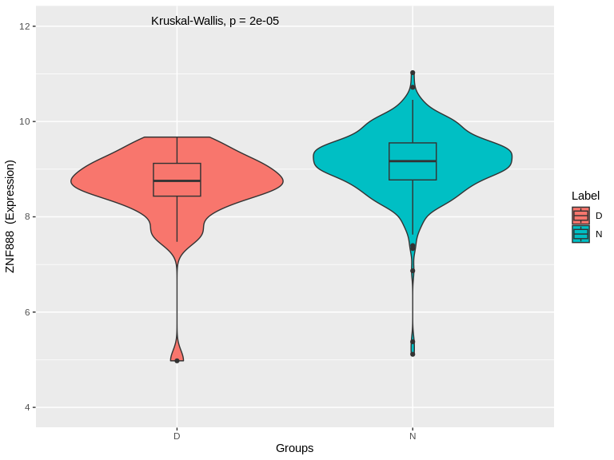

[output not shown]

[output cut: 42 more lines]

[output not shown]

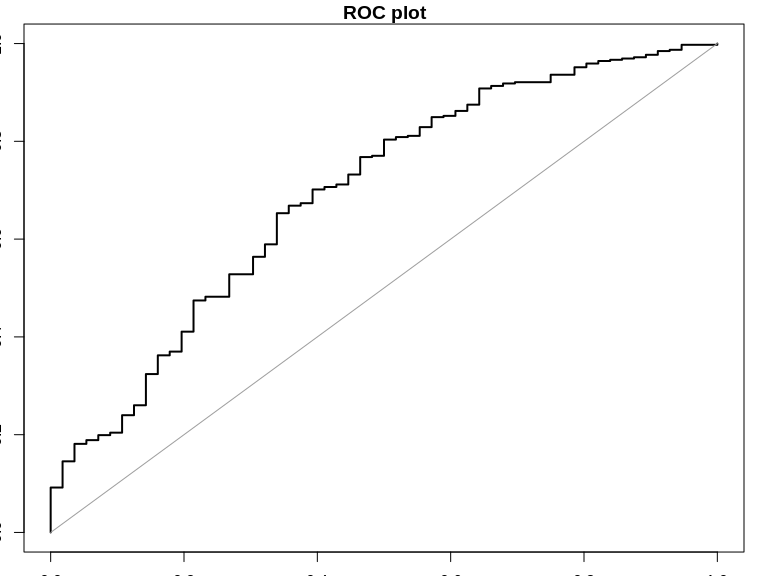

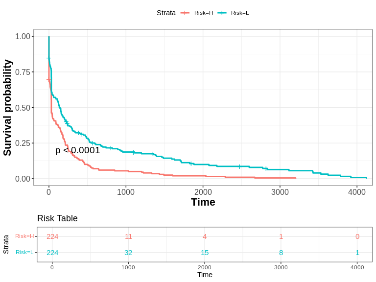

```r
# Access final_expre_matrix_prognostic_markers
final_data <- result_riskscore_model$final_expre_matrix_prognostic_markers
#head(final_data[1:5,1:5])
merged_high_low_risk <- result_riskscore_model$merged_high_low_risk
fit6 <- survfit(Surv(days_to_last_followup, vital_status) ~ Risk, data = merged_high_low_risk)
#  png("survival_plot.png")
  ggsurvplot(
    fit6,
    pval = TRUE,
    conf.int = FALSE,
    font.main = c(20, "bold"),
    font.submain = c(20, "bold"),
    font.caption = c(20, "bold"),
    font.x = c(16, "bold"),
    font.y = c(16, "bold"),
    font.tickslab = c(12, "plain"),
    ggtheme = theme_bw(),
    risk.table = TRUE,
    risk.table.col = "strata",
    risk.table.fontsize = 4,
    risk.table.title = "Risk Table",
    risk.table.y.text = TRUE
  )
```

[output not shown]

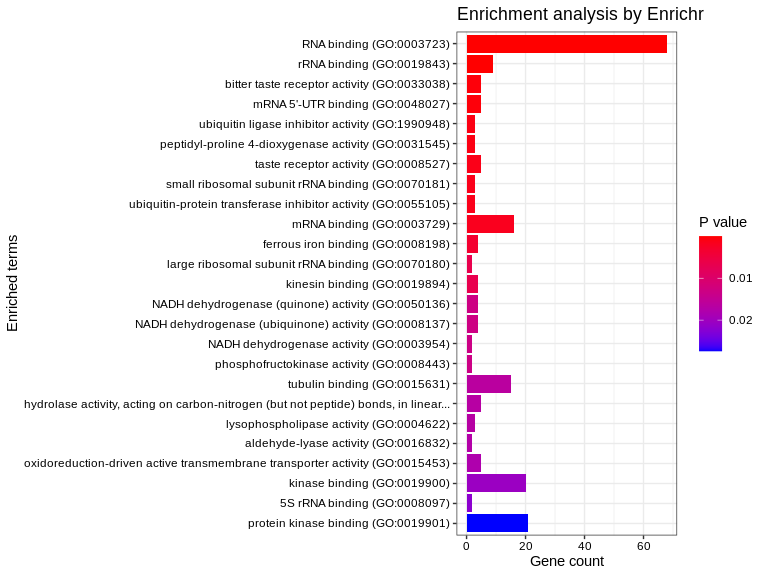

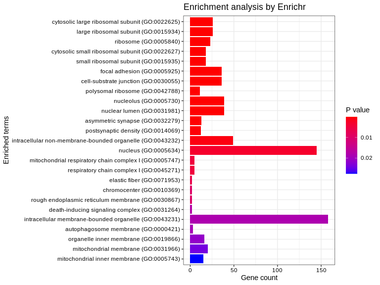

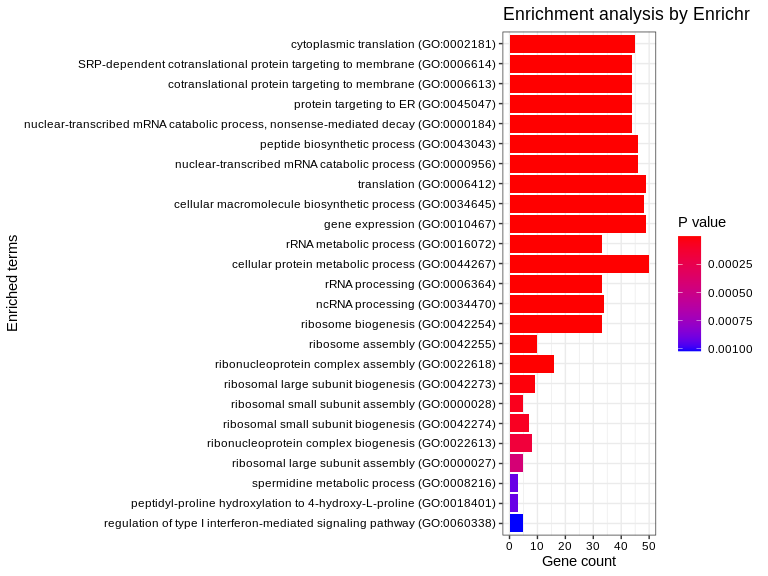

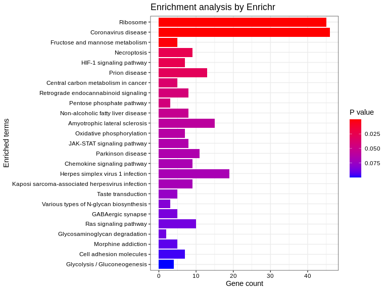

```r
## fifth function ###
lncRNA_expression <- final_data
PCG_expression <- PCG_matrix
Correlation_with_PCGs_and_functional_enrichment <- function(lncRNA_expression, PCG_expression) {

  result_df_Expr_PCGs <- PCG_expression
  prognostic_markers_expression <- lncRNA_expression
  columns_to_exclude <- c("vital_status", "days_to_last_followup")

  # Exclude columns by names
  prognostic_markers_expression <- prognostic_markers_expression[, -which(names(prognostic_markers_expression) %in% columns_to_exclude)]
  prognostic_markers_expression.t <- t(prognostic_markers_expression)

  # Get row names
  row_names <- rownames(prognostic_markers_expression.t)

  # Create a list to store individual data frames
  correlation_dfs <- list()

  # Iterate over each row and calculate correlation
  for (row_name in row_names) {
    row_data <- prognostic_markers_expression.t[row_name, , drop = FALSE]
    row_df <- data.frame(row_data)
    row_df$rowname <- row_name  # Add a column for row name

    # Transpose the PCG matrix and order by colnames
    result_df_Expr_PCGs.t <- t(result_df_Expr_PCGs)
    colnames(result_df_Expr_PCGs.t) <- gsub("-", ".", colnames(result_df_Expr_PCGs.t))
    result_df_Expr_PCGs.t <- result_df_Expr_PCGs.t[, order(colnames(result_df_Expr_PCGs.t))]

    # Calculate correlation
    correlation_values <- cor(t(row_data), t(result_df_Expr_PCGs.t))

    # Create a data frame with correlation values
    correlation_df <- data.frame(lncRNA = row_name, correlation_values)

    # Append to the list
    correlation_dfs[[ row_name]] <- correlation_df
  }

  # Remove the first column (lncRNA) from each data frame
  correlation_dfs <- lapply(correlation_dfs, function(df) df[, -1, drop = FALSE])

  for (i in seq_along(correlation_dfs)) {
    correlation_dfs[[i]] <- t(correlation_dfs[[i]])
  }

  correlation_dfs <- lapply(correlation_dfs, function(df) df[order(-df[, 1]), ])

  # Function to get top 50 genes for a given lncRNA
  get_top_50_genes <- function(correlation_values) {
    return(head(correlation_values, 50))
  }

  # Initialize a list to store top 50 genes for each lncRNA
  top_50_genes_list <- list()

  # Loop through each lncRNA and store top 50 genes in the list
  for (lncRNA in names(correlation_dfs)) {
    top_50_genes <- get_top_50_genes(correlation_dfs[[lncRNA]])
    top_50_genes_list[[lncRNA]] <- top_50_genes
  }

  gene_names_list <- list()


  # Create a directory for storing enrichment results if it doesn't exist
  output_directory <- "enrichment_result"
  dir.create(output_directory, recursive = TRUE)

  # Loop through each lncRNA and store gene names in the list
  for (lncRNA in names(top_50_genes_list)) {
    gene_names <- names(top_50_genes_list[[lncRNA]])
    gene_names_list[[lncRNA]] <- gene_names
  }

  #### 1. if want a combined Gene ontology enrichment for all lncRNAs ####
  # Display the result
  # print(gene_names_list)
  library(enrichR)
  # Now use enrichr
  listEnrichrSites()
  setEnrichrSite("Enrichr")
  websiteLive <- TRUE
  dbs <- listEnrichrDbs()
  if (is.null(dbs)) websiteLive <- FALSE
  if (websiteLive) head(dbs)
  plot_width = 5
  plot_height = 7

  dbs <- c("GO_Molecular_Function_2021", "GO_Cellular_Component_2021", "GO_Biological_Process_2021", "KEGG_2021_Human")

  combined_list <- unlist(gene_names_list)
  combined_list
  enriched <- enrichR::enrichr(combined_list, dbs)
  # Set dimensions for the plot
  for (i in seq_along(enriched)) {
   plot <- plotEnrich(enriched[[i]], showTerms = 25, numChar = 80, y = "Count", orderBy = "P.value")
   print(plot)
   ggplot2::ggsave(paste0(output_directory, "/", "plot_",  names(enriched)[i], ".png"), device = "png", width = plot_width, height = plot_height)
    write.table(enriched[[i]], file = paste0(output_directory, "/", names(enriched)[i], ".txt"), sep = "\t", quote = FALSE)
  }
  # Return the results
  return(list(
    correlation_dfs = correlation_dfs,
    gene_names_list = gene_names_list
  ))
}
## usage###
result_enrichment <- Correlation_with_PCGs_and_functional_enrichment(final_data, PCG_expression)
```

```r
Correlation_dfs <- result_enrichment$correlation_dfs
str(Correlation_dfs)
```

```
#> List of 11
#>  $ GAS5     : Named num [1:18080] 0.74 0.739 0.724 0.695 0.693 ...
#>   ..- attr(*, "names")= chr [1:18080] "RPL12" "RPL10A" "RPL31" "RPL37A" ...
#>  $ FAM85B   : Named num [1:18080] 0.37 0.348 0.345 0.342 0.339 ...
#>   ..- attr(*, "names")= chr [1:18080] "HMBOX1" "GOLGB1" "TNKS" "KIAA1109" ...
#>  $ BMS1P4   : Named num [1:18080] 0.607 0.605 0.6 0.591 0.59 ...
#>   ..- attr(*, "names")= chr [1:18080] "DDX47" "EIF4A1" "NDUFV2" "WDR27" ...
#>  $ LINC00115: Named num [1:18080] 0.636 0.636 0.584 0.559 0.553 ...
#>   ..- attr(*, "names")= chr [1:18080] "DHPS" "CCNL2" "CDK5RAP3" "CSAD" ...
#>  $ LINC00847: Named num [1:18080] 0.517 0.477 0.474 0.464 0.464 ...
#>   ..- attr(*, "names")= chr [1:18080] "HEXA" "TXNDC5" "TOMM5" "ABHD16A" ...
#>  $ C10orf95 : Named num [1:18080] 0.696 0.685 0.68 0.673 0.672 ...
#>   ..- attr(*, "names")= chr [1:18080] "PCBP1" "PDF" "NUDT3" "ENDOG" ...
#>  $ C1orf229 : Named num [1:18080] 0.31 0.309 0.305 0.304 0.299 ...
#>   ..- attr(*, "names")= chr [1:18080] "GTF2IRD2" "ZNF763" "TSPYL4" "DLEC1" ...
#>  $ MIR210HG : Named num [1:18080] 0.612 0.612 0.6 0.6 0.587 ...
#>   ..- attr(*, "names")= chr [1:18080] "ALDOC" "NDRG1" "SLC16A3" "EGLN3" ...
#>  $ MIAT     : Named num [1:18080] 0.791 0.737 0.735 0.728 0.719 ...
#>   ..- attr(*, "names")= chr [1:18080] "NLRC3" "TRAF3IP3" "SLFN12L" "CLEC2D" ...
#>  $ PCAT6    : Named num [1:18080] 0.525 0.525 0.506 0.503 0.498 ...
#>   ..- attr(*, "names")= chr [1:18080] "CRTC2" "CDIPT" "TUT1" "SSH3" ...
#>  $ FENDRR   : Named num [1:18080] 0.891 0.813 0.81 0.763 0.745 ...
#>   ..- attr(*, "names")= chr [1:18080] "FOXF1" "PCDH18" "FOXF2" "TCF21" ...
```

```r
gene_names_list = result_enrichment$gene_names_list
head(gene_names_list)
```

```
#> $GAS5
#>  [1] "RPL12"    "RPL10A"   "RPL31"    "RPL37A"   "RPS18"    "RPL34"
#>  [7] "RPL35A"   "RPS6"     "RPS8"     "RPS12"    "RPS13"    "RPS11"
#> [13] "RPL7A"    "RPS3"     "RPL13A"   "RPL32"    "RPS14"    "EEF1B2"
#> [19] "RPS27A"   "RPS15A"   "RPL5"     "RPL37"    "RPL27A"   "RPS27"
#> [25] "RPSA"     "RPLP0"    "RPL29"    "RPL27"    "EEF1A1"   "RPL3"
#> [31] "DAP3"     "CCNB1IP1" "RPS16"    "RPL15"    "RPL11"    "RPL18"
#> [37] "RPL38"    "RPL35"    "RPS9"     "C1orf43"  "RPL36"    "RPL23A"
#> [43] "RPL30"    "RPS5"     "UFC1"     "RPS29"    "RPS19"    "HINT1"
#> [49] "RPL41"    "NACA"
#>
#> $FAM85B
#>  [1] "HMBOX1"     "GOLGB1"     "TNKS"       "KIAA1109"   "ANKRD36C"
#>  [6] "MTMR9"      "ANKRD36B"   "NBEAL1"     "FAM106A"    "EXOC6B"
#> [11] "PCM1"       "REV3L"      "MYO9A"      "LPP"        "REL"
```

[output cut: 52 more lines]